# 3421-Homework 5- Greg Wells ID:1001995134

2023-03-10

## Homework 5 Question A1

### A:Data Visualization 1. Load the iris dataset into R and explore its structure and summary statistics.

```r
library(tidyverse,ggplot2)
library(datasets)
head(iris)
```

```
##   Sepal.Length Sepal.Width Petal.Length Petal.Width Species
## 1          5.1         3.5          1.4         0.2  setosa
## 2          4.9         3.0          1.4         0.2  setosa
## 3          4.7         3.2          1.3         0.2  setosa
## 4          4.6         3.1          1.5         0.2  setosa
## 5          5.0         3.6          1.4         0.2  setosa
## 6          5.4         3.9          1.7         0.4  setosa
```

```r
tail(iris)
```

```
##     Sepal.Length Sepal.Width Petal.Length Petal.Width   Species
## 145          6.7         3.3          5.7         2.5 virginica
## 146          6.7         3.0          5.2         2.3 virginica
## 147          6.3         2.5          5.0         1.9 virginica
## 148          6.5         3.0          5.2         2.0 virginica
## 149          6.2         3.4          5.4         2.3 virginica
## 150          5.9         3.0          5.1         1.8 virginica
```

```r
names(iris)
```

```
## [1] "Sepal.Length" "Sepal.Width"  "Petal.Length" "Petal.Width"  "Species"
```

```r
str(iris)
```

```
## 'data.frame':    150 obs. of  5 variables:
##  $ Sepal.Length: num  5.1 4.9 4.7 4.6 5 5.4 4.6 5 4.4 4.9 ...
##  $ Sepal.Width : num  3.5 3 3.2 3.1 3.6 3.9 3.4 3.4 2.9 3.1 ...
##  $ Petal.Length: num  1.4 1.4 1.3 1.5 1.4 1.7 1.4 1.5 1.4 1.5 ...
##  $ Petal.Width : num  0.2 0.2 0.2 0.2 0.2 0.4 0.3 0.2 0.2 0.1 ...
##  $ Species     : Factor w/ 3 levels "setosa","versicolor",..: 1 1 1 1 1 1 1 1 1 1 ...
```

```r
summary(iris)
```

```
##   Sepal.Length    Sepal.Width     Petal.Length    Petal.Width
##  Min.   :4.300   Min.   :2.000   Min.   :1.000   Min.   :0.100
##  1st Qu.:5.100   1st Qu.:2.800   1st Qu.:1.600   1st Qu.:0.300
##  Median :5.800   Median :3.000   Median :4.350   Median :1.300
##  Mean   :5.843   Mean   :3.057   Mean   :3.758   Mean   :1.199
##  3rd Qu.:6.400   3rd Qu.:3.300   3rd Qu.:5.100   3rd Qu.:1.800
##  Max.   :7.900   Max.   :4.400   Max.   :6.900   Max.   :2.500
##        Species
##  setosa    :50
##  versicolor:50
##  virginica :50
##
##
##
```

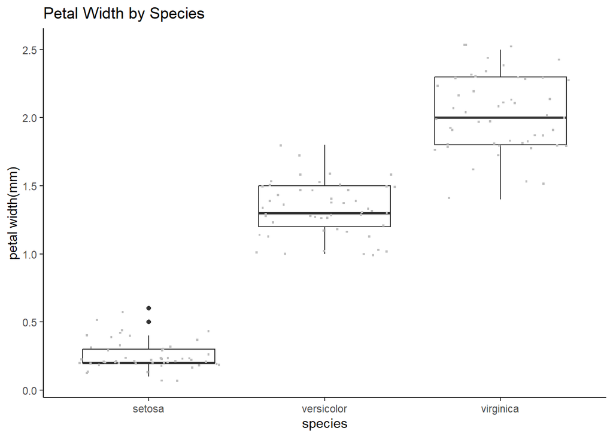

```r
#plot(iris$Species,iris$Petal.Width)

ggplot(iris, aes(x = Species, y = Petal.Width)) +
    geom_boxplot() + geom_jitter(shape = 15,color = "gray",size=0.5)+
    labs(y = "petal width(mm)", x = "species") +
    ggtitle("Petal Width by Species") +theme_classic() + theme(legend.position = "none")
```

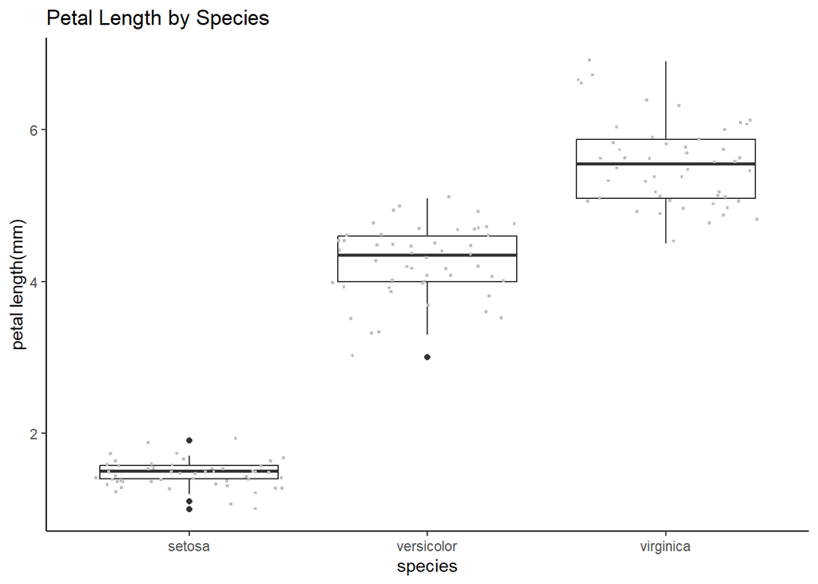

```r
ggplot(iris, aes(x = Species, y = Petal.Length)) +
    geom_boxplot() + geom_jitter(shape = 15,color = "gray",size=0.5)+
    labs(y = "petal length(mm)", x = "species") +
    ggtitle("Petal Length by Species") +theme_classic() + theme(legend.position = "none")
```

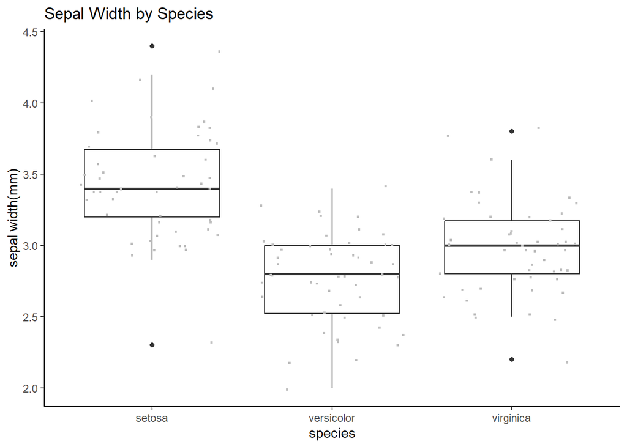

```r
ggplot(iris, aes(x = Species, y = Sepal.Width)) +
    geom_boxplot() + geom_jitter(shape = 15,color = "gray",size=0.5)+
    labs(y = "sepal width(mm)", x = "species") +
    ggtitle("Sepal Width by Species") +theme_classic() + theme(legend.position = "none")
```

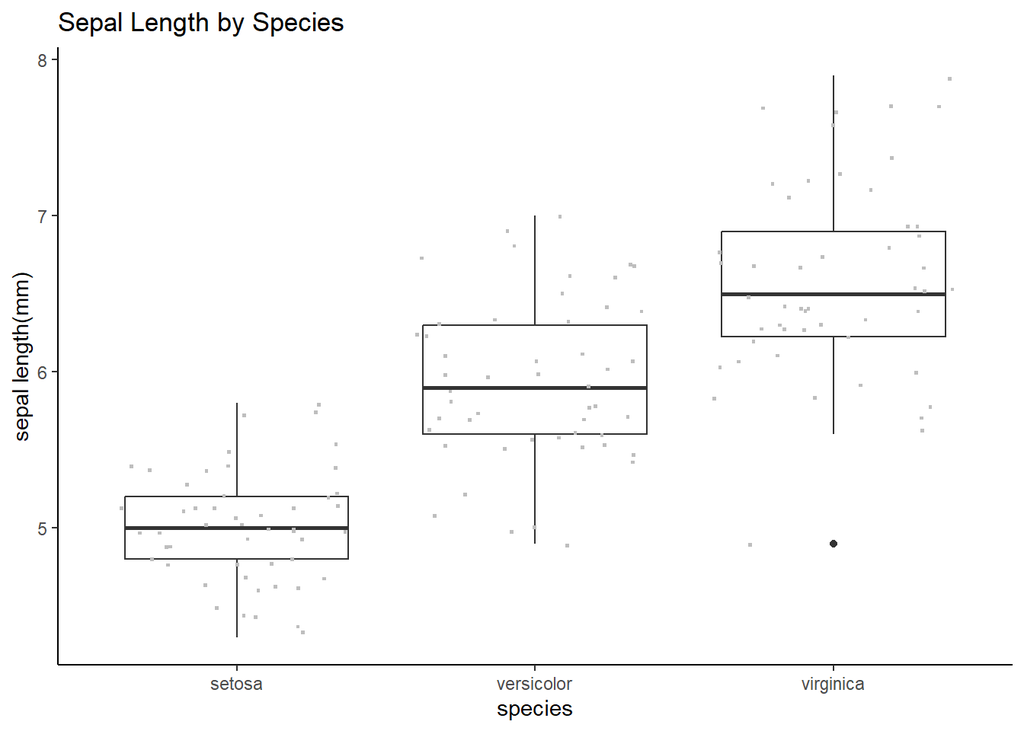

```r
ggplot(iris, aes(x = Species, y = Sepal.Length)) +
    geom_boxplot() + geom_jitter(shape = 15,color = "gray",size=0.5)+
    labs(y = "sepal length(mm)", x = "species") +
    ggtitle("Sepal Length by Species") +theme_classic() + theme(legend.position = "none")
```

```r
cor(as.numeric(iris$Species),iris$Petal.Width,method="pearson")
```

```
## [1] 0.9565473
```

```r
cor(as.numeric(iris$Species),iris$Petal.Length,method="pearson")
```

```
## [1] 0.9490347
```

```r
cor(as.numeric(iris$Species),iris$Sepal.Length,method="pearson")
```

```
## [1] 0.7825612
```

```r
cor(as.numeric(iris$Species),iris$Sepal.Width,method="pearson")
```

```
## [1] -0.4266576
```

```r
#cor(as.numeric(iris$Species),iris$Petal.Width,method="pearson")
#cor(as.numeric(iris$Species),iris$Petal.Width,method="kendal")
#cor(as.numeric(iris$Species),iris$Petal.Width,method="spearman")
#cor(as.numeric(iris$Species),iris$Petal.Width,method="kendal")

#library(corrplot)
#library(RColorBrewer)
#change the type=red/white  to 0 or 1 respectively
#df_numeric<-within(df, type <- sapply(df$type,switch,'red'=0,'white'=1,'undefined'=""))

#W<-cor(df_numeric)
#corrplot(W, type="upper", order="hclust",
#         col=brewer.pal(n=8, name="RdYlBu"))

print("Answer: The iris dataset contains measurements of petal and sepal width & length for 3 species of iris.",quote=FALSE)
```

```
## [1] Answer: The iris dataset contains measurements of petal and sepal width & length for 3 species of iris.
```

## Homework 5 Question A2

### A:Data Visualization 2. Create a scatterplot of the sepal length and width of the iris flowers. Use different colors to represent the different species of flowers.

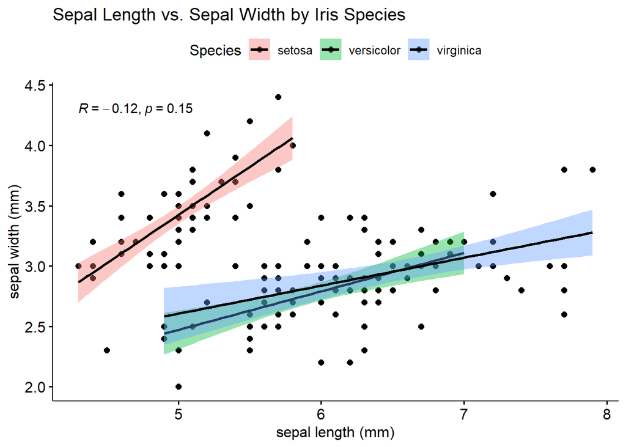

```r
library("ggpubr")
ggscatter(iris, x = "Sepal.Length", y = "Sepal.Width", title="Sepal Length vs. Sepal Width by Iris Species",
          add = "reg.line", conf.int = TRUE,
          cor.coef = TRUE, cor.method = "pearson",fill="Species",
          xlab = "sepal length (mm)", ylab = "sepal width (mm)")
```

## Homework 5 Question A3

### A:Data Visualization 3. Create a boxplot of the petal length for each species of flower.

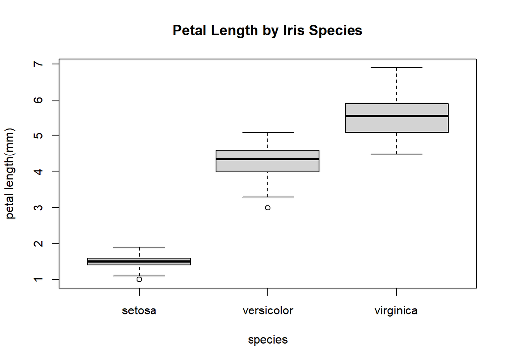

```r
boxplot(Petal.Length~Species,data=iris,xlab="species", ylab="petal length(mm)",main="Petal Length by Iris Species")
```

## Homework 5 Question A4

### A:Data Visualization 4. Create a histogram of the sepal width of the iris flowers.

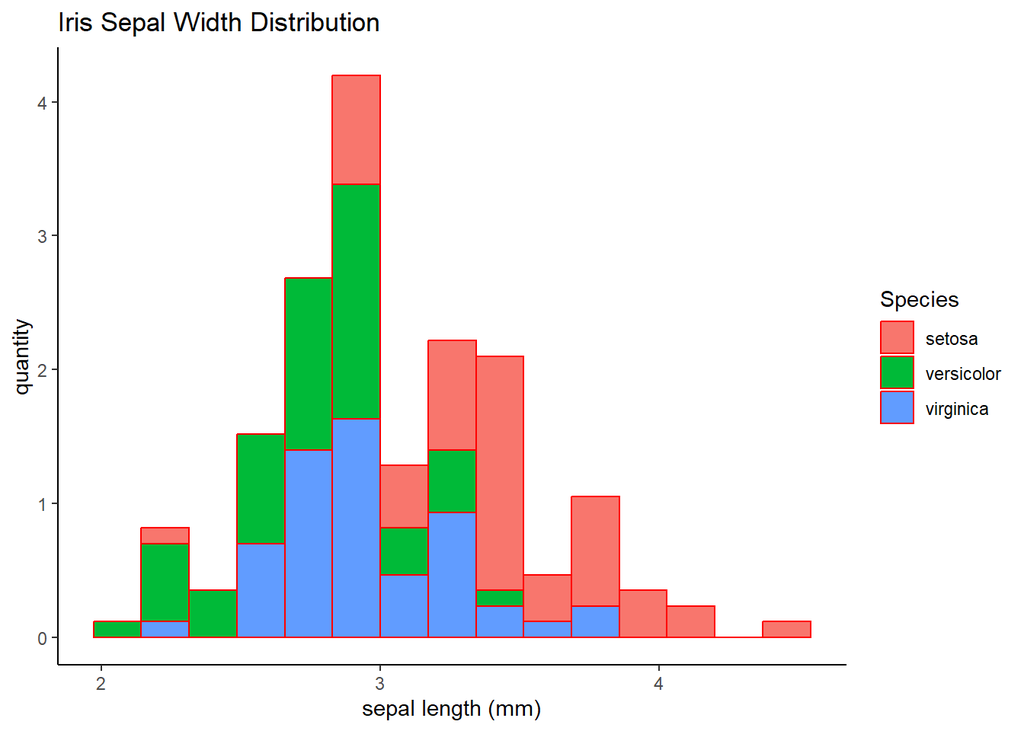

```r
ggplot()+geom_histogram(data=iris,bins=15,aes(x=Sepal.Width,y=after_stat(density),fill=Species),color="red")+theme_classic()+ggtitle("Iris Sepal Width Distribution")+labs(y= "quantity", x = "sepal length (mm)")
```

## Homework 5 Question B1

### B:Linear Regression 1. Load the mtcars dataset into R and explore its structure and summary statistics.

```r
#install.packages("corrplot")
library(corrplot)
library(tidyverse)
library(ggplot2)

#Loading data
data(mtcars)

head(mtcars)
```

```
##                    mpg cyl disp  hp drat    wt  qsec vs am gear carb
## Mazda RX4         21.0   6  160 110 3.90 2.620 16.46  0  1    4    4
## Mazda RX4 Wag     21.0   6  160 110 3.90 2.875 17.02  0  1    4    4
## Datsun 710        22.8   4  108  93 3.85 2.320 18.61  1  1    4    1
## Hornet 4 Drive    21.4   6  258 110 3.08 3.215 19.44  1  0    3    1
## Hornet Sportabout 18.7   8  360 175 3.15 3.440 17.02  0  0    3    2
## Valiant           18.1   6  225 105 2.76 3.460 20.22  1  0    3    1
```

```r
#tail(mtcars)
names(mtcars)
```

```
##  [1] "mpg"  "cyl"  "disp" "hp"   "drat" "wt"   "qsec" "vs"   "am"   "gear"
## [11] "carb"
```

```r
str(mtcars)
```

```
## 'data.frame':    32 obs. of  11 variables:
##  $ mpg : num  21 21 22.8 21.4 18.7 18.1 14.3 24.4 22.8 19.2 ...
##  $ cyl : num  6 6 4 6 8 6 8 4 4 6 ...
##  $ disp: num  160 160 108 258 360 ...
##  $ hp  : num  110 110 93 110 175 105 245 62 95 123 ...
##  $ drat: num  3.9 3.9 3.85 3.08 3.15 2.76 3.21 3.69 3.92 3.92 ...
##  $ wt  : num  2.62 2.88 2.32 3.21 3.44 ...
##  $ qsec: num  16.5 17 18.6 19.4 17 ...
##  $ vs  : num  0 0 1 1 0 1 0 1 1 1 ...
##  $ am  : num  1 1 1 0 0 0 0 0 0 0 ...
##  $ gear: num  4 4 4 3 3 3 3 4 4 4 ...
##  $ carb: num  4 4 1 1 2 1 4 2 2 4 ...
```

```r
summary(mtcars)
```

```
##       mpg             cyl             disp             hp
##  Min.   :10.40   Min.   :4.000   Min.   : 71.1   Min.   : 52.0
##  1st Qu.:15.43   1st Qu.:4.000   1st Qu.:120.8   1st Qu.: 96.5
##  Median :19.20   Median :6.000   Median :196.3   Median :123.0
##  Mean   :20.09   Mean   :6.188   Mean   :230.7   Mean   :146.7
##  3rd Qu.:22.80   3rd Qu.:8.000   3rd Qu.:326.0   3rd Qu.:180.0
##  Max.   :33.90   Max.   :8.000   Max.   :472.0   Max.   :335.0
##       drat             wt             qsec             vs
##  Min.   :2.760   Min.   :1.513   Min.   :14.50   Min.   :0.0000
##  1st Qu.:3.080   1st Qu.:2.581   1st Qu.:16.89   1st Qu.:0.0000
##  Median :3.695   Median :3.325   Median :17.71   Median :0.0000
##  Mean   :3.597   Mean   :3.217   Mean   :17.85   Mean   :0.4375
##  3rd Qu.:3.920   3rd Qu.:3.610   3rd Qu.:18.90   3rd Qu.:1.0000
##  Max.   :4.930   Max.   :5.424   Max.   :22.90   Max.   :1.0000
##        am              gear            carb
##  Min.   :0.0000   Min.   :3.000   Min.   :1.000
##  1st Qu.:0.0000   1st Qu.:3.000   1st Qu.:2.000
##  Median :0.0000   Median :4.000   Median :2.000
##  Mean   :0.4062   Mean   :3.688   Mean   :2.812
##  3rd Qu.:1.0000   3rd Qu.:4.000   3rd Qu.:4.000
##  Max.   :1.0000   Max.   :5.000   Max.   :8.000
```

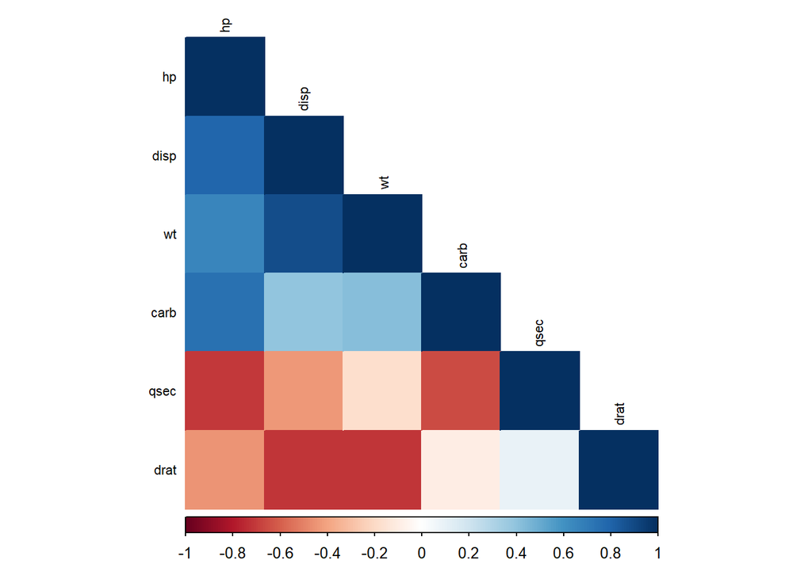

```r
mtcars$am   = as.factor(mtcars$am)
mtcars$cyl  = as.factor(mtcars$cyl)
mtcars$vs   = as.factor(mtcars$vs)
mtcars$gear = as.factor(mtcars$gear)
#Dropping dependent variable for calculating Multicollinearity
mtcars_a = subset(mtcars, select = -c(mpg))

#Identifying numeric variables
numericData <- mtcars_a[sapply(mtcars_a, is.numeric)]

#Calculating Correlation
descrCor <- cor(numericData)

# Visualize Correlation Matrix
corrplot(descrCor, order = "FPC", method = "color", type = "lower", tl.cex = 0.7, tl.col = rgb(0, 0, 0))
```

```r
print("Answer: The mtcars dataset contains 11 parameters for a variety of car models.",quote=FALSE)
```

```
## [1] Answer: The mtcars dataset contains 11 parameters for a variety of car models.
```